# Optimal Treatment Analysis

## Outcome Variable

**Outcome Variable:** ever_stunted

## Predictor Variables

**Intervention Variable:** nhh

**Adjustment Set:**

- arm
- W_mage
- meducyrs
- feducyrs
- W_mhtcm
- W_mwtkg
- W_mbmi
- W_nrooms
- impfloor
- impsan
- safeh20
- delta_W_mage
- delta_meducyrs
- delta_feducyrs
- delta_W_mhtcm
- delta_W_mwtkg
- delta_W_mbmi
- delta_W_nrooms
- delta_impfloor
- delta_impsan
- delta_safeh20

## Stratifying Variables

The analysis was stratified on these variable(s):

- agecat
- studyid
- country

## Data Summary

| agecat | studyid | country | nhh | ever_stunted | n_cell | n |
| --- | --- | --- | --- | --- | --- | --- |
| 0-24 months | ki1000108-IRC | INDIA | 3 or less | 0 | 25 | 410 |
| 0-24 months | ki1000108-IRC | INDIA | 3 or less | 1 | 33 | 410 |
| 0-24 months | ki1000108-IRC | INDIA | 4-5 | 0 | 52 | 410 |
| 0-24 months | ki1000108-IRC | INDIA | 4-5 | 1 | 106 | 410 |
| 0-24 months | ki1000108-IRC | INDIA | 6-7 | 0 | 41 | 410 |
| 0-24 months | ki1000108-IRC | INDIA | 6-7 | 1 | 66 | 410 |
| 0-24 months | ki1000108-IRC | INDIA | 8+ | 0 | 29 | 410 |
| 0-24 months | ki1000108-IRC | INDIA | 8+ | 1 | 58 | 410 |
| 0-24 months | ki1000304b-SAS-FoodSuppl | INDIA | 3 or less | 0 | 9 | 418 |
| 0-24 months | ki1000304b-SAS-FoodSuppl | INDIA | 3 or less | 1 | 29 | 418 |
| 0-24 months | ki1000304b-SAS-FoodSuppl | INDIA | 4-5 | 0 | 35 | 418 |
| 0-24 months | ki1000304b-SAS-FoodSuppl | INDIA | 4-5 | 1 | 148 | 418 |
| 0-24 months | ki1000304b-SAS-FoodSuppl | INDIA | 6-7 | 0 | 16 | 418 |
| 0-24 months | ki1000304b-SAS-FoodSuppl | INDIA | 6-7 | 1 | 111 | 418 |
| 0-24 months | ki1000304b-SAS-FoodSuppl | INDIA | 8+ | 0 | 12 | 418 |
| 0-24 months | ki1000304b-SAS-FoodSuppl | INDIA | 8+ | 1 | 58 | 418 |
| 0-24 months | ki1017093-NIH-Birth | BANGLADESH | 3 or less | 0 | 47 | 629 |
| 0-24 months | ki1017093-NIH-Birth | BANGLADESH | 3 or less | 1 | 70 | 629 |
| 0-24 months | ki1017093-NIH-Birth | BANGLADESH | 4-5 | 0 | 77 | 629 |
| 0-24 months | ki1017093-NIH-Birth | BANGLADESH | 4-5 | 1 | 187 | 629 |
| 0-24 months | ki1017093-NIH-Birth | BANGLADESH | 6-7 | 0 | 42 | 629 |
| 0-24 months | ki1017093-NIH-Birth | BANGLADESH | 6-7 | 1 | 100 | 629 |
| 0-24 months | ki1017093-NIH-Birth | BANGLADESH | 8+ | 0 | 45 | 629 |
| 0-24 months | ki1017093-NIH-Birth | BANGLADESH | 8+ | 1 | 61 | 629 |
| 0-24 months | ki1017093b-PROVIDE | BANGLADESH | 3 or less | 0 | 83 | 700 |
| 0-24 months | ki1017093b-PROVIDE | BANGLADESH | 3 or less | 1 | 57 | 700 |
| 0-24 months | ki1017093b-PROVIDE | BANGLADESH | 4-5 | 0 | 179 | 700 |
| 0-24 months | ki1017093b-PROVIDE | BANGLADESH | 4-5 | 1 | 143 | 700 |
| 0-24 months | ki1017093b-PROVIDE | BANGLADESH | 6-7 | 0 | 84 | 700 |
| 0-24 months | ki1017093b-PROVIDE | BANGLADESH | 6-7 | 1 | 67 | 700 |

[output cut: 114 more lines]

The following strata were considered:

- agecat: 0-24 months, studyid: ki1000108-IRC, country: INDIA
- agecat: 0-24 months, studyid: ki1000304b-SAS-FoodSuppl, country: INDIA
- agecat: 0-24 months, studyid: ki1017093-NIH-Birth, country: BANGLADESH
- agecat: 0-24 months, studyid: ki1017093b-PROVIDE, country: BANGLADESH
- agecat: 0-24 months, studyid: ki1017093c-NIH-Crypto, country: BANGLADESH
- agecat: 0-24 months, studyid: ki1148112-LCNI-5, country: MALAWI
- agecat: 0-6 months, studyid: ki1000108-IRC, country: INDIA
- agecat: 0-6 months, studyid: ki1000304b-SAS-FoodSuppl, country: INDIA
- agecat: 0-6 months, studyid: ki1017093-NIH-Birth, country: BANGLADESH
- agecat: 0-6 months, studyid: ki1017093b-PROVIDE, country: BANGLADESH
- agecat: 0-6 months, studyid: ki1017093c-NIH-Crypto, country: BANGLADESH
- agecat: 0-6 months, studyid: ki1148112-LCNI-5, country: MALAWI
- agecat: 6-24 months, studyid: ki1000108-IRC, country: INDIA
- agecat: 6-24 months, studyid: ki1000304b-SAS-FoodSuppl, country: INDIA
- agecat: 6-24 months, studyid: ki1017093-NIH-Birth, country: BANGLADESH
- agecat: 6-24 months, studyid: ki1017093b-PROVIDE, country: BANGLADESH
- agecat: 6-24 months, studyid: ki1017093c-NIH-Crypto, country: BANGLADESH
- agecat: 6-24 months, studyid: ki1148112-LCNI-5, country: MALAWI

### Dropped Strata

Some strata were dropped due to rare outcomes:

- agecat: 0-6 months, studyid: ki1148112-LCNI-5, country: MALAWI

## Methods Detail

We’re interested in the causal parameters $E[Y_a]$ for all values of $a \in \mathcal{A}$. These parameters represent the mean outcome if, possibly contrary to fact, we intervened to set all units to have $A=a$. Under the randomization and positivity assumptions, these are identified by the statistical parameters $\psi_a=E_W[E_{Y|A,W}(Y|A=a,W)]$. In addition, we’re interested in the mean of $Y$, $E[Y]$ under no intervention (the observed mean). We will estimate these parameters by using SuperLearner to fit the relevant likelihood factors – $E_{Y|A,W}(Y|A=a,W)$ and $p(A=a|W)$, and then updating our likelihood fit using a joint TMLE.

For unadjusted analyses ($W=\{\}$), initial likelihoods were estimated using Lrnr_glm to estimate the simple $E(Y|A)$ and Lrnr_mean to estimate $p(A)$. For adjusted analyses, a small library containing Lrnr_glmnet, Lrnr_xgboost, and Lrnr_mean was used.

Having estimated these parameters, we will then use the delta method to estimate relative risks and attributable risks relative to a prespecified baseline level of $A$.

# Results Detail

## Results Plots

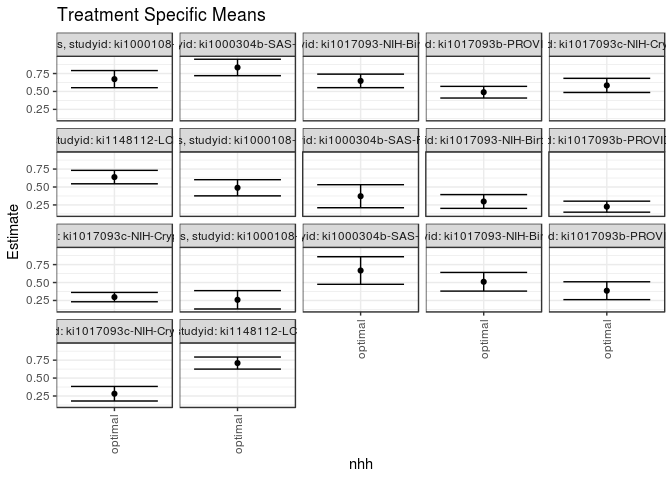

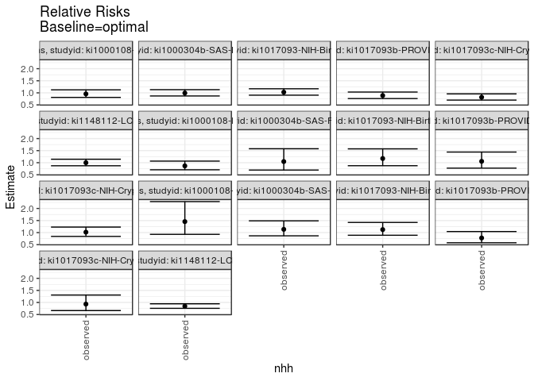

## Results Table

### Parameter: TSM

| agecat | studyid | country | intervention_level | baseline_level | estimate | ci_lower | ci_upper |
| --- | --- | --- | --- | --- | --- | --- | --- |
| 0-24 months | ki1000108-IRC | INDIA | optimal | NA | 0.6716985 | 0.5522987 | 0.7910982 |
| 0-24 months | ki1000304b-SAS-FoodSuppl | INDIA | optimal | NA | 0.8346524 | 0.7201028 | 0.9492021 |
| 0-24 months | ki1017093-NIH-Birth | BANGLADESH | optimal | NA | 0.6470733 | 0.5527408 | 0.7414058 |
| 0-24 months | ki1017093b-PROVIDE | BANGLADESH | optimal | NA | 0.4896272 | 0.4082846 | 0.5709698 |
| 0-24 months | ki1017093c-NIH-Crypto | BANGLADESH | optimal | NA | 0.5844091 | 0.4857701 | 0.6830481 |
| 0-24 months | ki1148112-LCNI-5 | MALAWI | optimal | NA | 0.6381137 | 0.5446786 | 0.7315488 |
| 0-6 months | ki1000108-IRC | INDIA | optimal | NA | 0.4890612 | 0.3761909 | 0.6019314 |
| 0-6 months | ki1000304b-SAS-FoodSuppl | INDIA | optimal | NA | 0.3716322 | 0.2109834 | 0.5322809 |
| 0-6 months | ki1017093-NIH-Birth | BANGLADESH | optimal | NA | 0.2979643 | 0.2019903 | 0.3939383 |
| 0-6 months | ki1017093b-PROVIDE | BANGLADESH | optimal | NA | 0.2258311 | 0.1489269 | 0.3027353 |
| 0-6 months | ki1017093c-NIH-Crypto | BANGLADESH | optimal | NA | 0.2970780 | 0.2320784 | 0.3620775 |
| 6-24 months | ki1000108-IRC | INDIA | optimal | NA | 0.2590249 | 0.1311259 | 0.3869239 |
| 6-24 months | ki1000304b-SAS-FoodSuppl | INDIA | optimal | NA | 0.6674838 | 0.4752327 | 0.8597350 |
| 6-24 months | ki1017093-NIH-Birth | BANGLADESH | optimal | NA | 0.5106509 | 0.3804793 | 0.6408226 |
| 6-24 months | ki1017093b-PROVIDE | BANGLADESH | optimal | NA | 0.3859833 | 0.2615221 | 0.5104444 |
| 6-24 months | ki1017093c-NIH-Crypto | BANGLADESH | optimal | NA | 0.2819676 | 0.1804318 | 0.3835035 |
| 6-24 months | ki1148112-LCNI-5 | MALAWI | optimal | NA | 0.7091513 | 0.6250958 | 0.7932068 |

### Parameter: E(Y)

| agecat | studyid | country | intervention_level | baseline_level | estimate | ci_lower | ci_upper |
| --- | --- | --- | --- | --- | --- | --- | --- |
| 0-24 months | ki1000108-IRC | INDIA | observed | NA | 0.6414634 | 0.5949863 | 0.6879405 |
| 0-24 months | ki1000304b-SAS-FoodSuppl | INDIA | observed | NA | 0.8277512 | 0.7915095 | 0.8639929 |
| 0-24 months | ki1017093-NIH-Birth | BANGLADESH | observed | NA | 0.6645469 | 0.6276196 | 0.7014742 |
| 0-24 months | ki1017093b-PROVIDE | BANGLADESH | observed | NA | 0.4342857 | 0.3975409 | 0.4710305 |
| 0-24 months | ki1017093c-NIH-Crypto | BANGLADESH | observed | NA | 0.4775726 | 0.4419904 | 0.5131548 |
| 0-24 months | ki1148112-LCNI-5 | MALAWI | observed | NA | 0.6376989 | 0.6047193 | 0.6706785 |
| 0-6 months | ki1000108-IRC | INDIA | observed | NA | 0.4243902 | 0.3764905 | 0.4722900 |
| 0-6 months | ki1000304b-SAS-FoodSuppl | INDIA | observed | NA | 0.3894231 | 0.3425088 | 0.4363374 |
| 0-6 months | ki1017093-NIH-Birth | BANGLADESH | observed | NA | 0.3497615 | 0.3124631 | 0.3870600 |
| 0-6 months | ki1017093b-PROVIDE | BANGLADESH | observed | NA | 0.2385714 | 0.2069753 | 0.2701675 |
| 0-6 months | ki1017093c-NIH-Crypto | BANGLADESH | observed | NA | 0.3021108 | 0.2694011 | 0.3348205 |
| 6-24 months | ki1000108-IRC | INDIA | observed | NA | 0.3771186 | 0.3151523 | 0.4390850 |
| 6-24 months | ki1000304b-SAS-FoodSuppl | INDIA | observed | NA | 0.7572016 | 0.7031798 | 0.8112234 |
| 6-24 months | ki1017093-NIH-Birth | BANGLADESH | observed | NA | 0.5739130 | 0.5216565 | 0.6261696 |
| 6-24 months | ki1017093b-PROVIDE | BANGLADESH | observed | NA | 0.2997812 | 0.2577294 | 0.3418330 |
| 6-24 months | ki1017093c-NIH-Crypto | BANGLADESH | observed | NA | 0.2628458 | 0.2244546 | 0.3012371 |
| 6-24 months | ki1148112-LCNI-5 | MALAWI | observed | NA | 0.6000000 | 0.5639396 | 0.6360604 |

### Parameter: RR

| agecat | studyid | country | intervention_level | baseline_level | estimate | ci_lower | ci_upper |
| --- | --- | --- | --- | --- | --- | --- | --- |
| 0-24 months | ki1000108-IRC | INDIA | observed | optimal | 0.9549872 | 0.8106797 | 1.1249825 |
| 0-24 months | ki1000304b-SAS-FoodSuppl | INDIA | observed | optimal | 0.9917316 | 0.8699957 | 1.1305016 |
| 0-24 months | ki1017093-NIH-Birth | BANGLADESH | observed | optimal | 1.0270040 | 0.9023095 | 1.1689308 |
| 0-24 months | ki1017093b-PROVIDE | BANGLADESH | observed | optimal | 0.8869722 | 0.7623532 | 1.0319622 |
| 0-24 months | ki1017093c-NIH-Crypto | BANGLADESH | observed | optimal | 0.8171888 | 0.6980385 | 0.9566771 |
| 0-24 months | ki1148112-LCNI-5 | MALAWI | observed | optimal | 0.9993499 | 0.8728149 | 1.1442292 |
| 0-6 months | ki1000108-IRC | INDIA | observed | optimal | 0.8677651 | 0.7060017 | 1.0665928 |
| 0-6 months | ki1000304b-SAS-FoodSuppl | INDIA | observed | optimal | 1.0478724 | 0.6955132 | 1.5787428 |
| 0-6 months | ki1017093-NIH-Birth | BANGLADESH | observed | optimal | 1.1738371 | 0.8755131 | 1.5738124 |
| 0-6 months | ki1017093b-PROVIDE | BANGLADESH | observed | optimal | 1.0564153 | 0.7740668 | 1.4417530 |
| 0-6 months | ki1017093c-NIH-Crypto | BANGLADESH | observed | optimal | 1.0169412 | 0.8417722 | 1.2285620 |
| 6-24 months | ki1000108-IRC | INDIA | observed | optimal | 1.4559166 | 0.9277994 | 2.2846458 |
| 6-24 months | ki1000304b-SAS-FoodSuppl | INDIA | observed | optimal | 1.1344119 | 0.8655666 | 1.4867607 |
| 6-24 months | ki1017093-NIH-Birth | BANGLADESH | observed | optimal | 1.1238852 | 0.8893461 | 1.4202773 |
| 6-24 months | ki1017093b-PROVIDE | BANGLADESH | observed | optimal | 0.7766689 | 0.5783602 | 1.0429737 |
| 6-24 months | ki1017093c-NIH-Crypto | BANGLADESH | observed | optimal | 0.9321844 | 0.6643735 | 1.3079507 |
| 6-24 months | ki1148112-LCNI-5 | MALAWI | observed | optimal | 0.8460818 | 0.7577339 | 0.9447306 |

### Parameter: PAR

| agecat | studyid | country | intervention_level | baseline_level | estimate | ci_lower | ci_upper |
| --- | --- | --- | --- | --- | --- | --- | --- |
| 0-24 months | ki1000108-IRC | INDIA | optimal | NA | -0.0302351 | -0.1402525 | 0.0797824 |
| 0-24 months | ki1000304b-SAS-FoodSuppl | INDIA | optimal | NA | -0.0069012 | -0.1162051 | 0.1024026 |
| 0-24 months | ki1017093-NIH-Birth | BANGLADESH | optimal | NA | 0.0174736 | -0.0661964 | 0.1011435 |
| 0-24 months | ki1017093b-PROVIDE | BANGLADESH | optimal | NA | -0.0553415 | -0.1291664 | 0.0184835 |
| 0-24 months | ki1017093c-NIH-Crypto | BANGLADESH | optimal | NA | -0.1068366 | -0.1986366 | -0.0150365 |
| 0-24 months | ki1148112-LCNI-5 | MALAWI | optimal | NA | -0.0004148 | -0.0868043 | 0.0859746 |
| 0-6 months | ki1000108-IRC | INDIA | optimal | NA | -0.0646709 | -0.1655108 | 0.0361689 |
| 0-6 months | ki1000304b-SAS-FoodSuppl | INDIA | optimal | NA | 0.0177909 | -0.1344493 | 0.1700311 |
| 0-6 months | ki1017093-NIH-Birth | BANGLADESH | optimal | NA | 0.0517972 | -0.0351816 | 0.1387760 |
| 0-6 months | ki1017093b-PROVIDE | BANGLADESH | optimal | NA | 0.0127403 | -0.0574733 | 0.0829540 |
| 0-6 months | ki1017093c-NIH-Crypto | BANGLADESH | optimal | NA | 0.0050328 | -0.0511255 | 0.0611912 |
| 6-24 months | ki1000108-IRC | INDIA | optimal | NA | 0.1180937 | 0.0015780 | 0.2346095 |
| 6-24 months | ki1000304b-SAS-FoodSuppl | INDIA | optimal | NA | 0.0897178 | -0.0901586 | 0.2695942 |
| 6-24 months | ki1017093-NIH-Birth | BANGLADESH | optimal | NA | 0.0632621 | -0.0561423 | 0.1826665 |
| 6-24 months | ki1017093b-PROVIDE | BANGLADESH | optimal | NA | -0.0862021 | -0.2002559 | 0.0278517 |
| 6-24 months | ki1017093c-NIH-Crypto | BANGLADESH | optimal | NA | -0.0191218 | -0.1144812 | 0.0762376 |
| 6-24 months | ki1148112-LCNI-5 | MALAWI | optimal | NA | -0.1091513 | -0.1867784 | -0.0315242 |

### Parameter: PAF

| agecat | studyid | country | intervention_level | baseline_level | estimate | ci_lower | ci_upper |
| --- | --- | --- | --- | --- | --- | --- | --- |
| 0-24 months | ki1000108-IRC | INDIA | optimal | NA | -0.0471345 | -0.2335327 | 0.1110973 |
| 0-24 months | ki1000304b-SAS-FoodSuppl | INDIA | optimal | NA | -0.0083373 | -0.1494309 | 0.1154369 |
| 0-24 months | ki1017093-NIH-Birth | BANGLADESH | optimal | NA | 0.0262940 | -0.1082672 | 0.1445173 |
| 0-24 months | ki1017093b-PROVIDE | BANGLADESH | optimal | NA | -0.1274310 | -0.3117279 | 0.0309723 |
| 0-24 months | ki1017093c-NIH-Crypto | BANGLADESH | optimal | NA | -0.2237075 | -0.4325857 | -0.0452848 |
| 0-24 months | ki1148112-LCNI-5 | MALAWI | optimal | NA | -0.0006505 | -0.1457183 | 0.1260492 |
| 0-6 months | ki1000108-IRC | INDIA | optimal | NA | -0.1523855 | -0.4164271 | 0.0624350 |
| 0-6 months | ki1000304b-SAS-FoodSuppl | INDIA | optimal | NA | 0.0456853 | -0.4377872 | 0.3665846 |
| 0-6 months | ki1017093-NIH-Birth | BANGLADESH | optimal | NA | 0.1480930 | -0.1421873 | 0.3646003 |
| 0-6 months | ki1017093b-PROVIDE | BANGLADESH | optimal | NA | 0.0534025 | -0.2918781 | 0.3063999 |
| 0-6 months | ki1017093c-NIH-Crypto | BANGLADESH | optimal | NA | 0.0166590 | -0.1879698 | 0.1860403 |
| 6-24 months | ki1000108-IRC | INDIA | optimal | NA | 0.3131474 | -0.0778192 | 0.5622954 |
| 6-24 months | ki1000304b-SAS-FoodSuppl | INDIA | optimal | NA | 0.1184860 | -0.1553125 | 0.3273968 |
| 6-24 months | ki1017093-NIH-Birth | BANGLADESH | optimal | NA | 0.1102294 | -0.1244216 | 0.2959121 |
| 6-24 months | ki1017093b-PROVIDE | BANGLADESH | optimal | NA | -0.2875500 | -0.7290262 | 0.0412031 |
| 6-24 months | ki1017093c-NIH-Crypto | BANGLADESH | optimal | NA | -0.0727491 | -0.5051774 | 0.2354452 |
| 6-24 months | ki1148112-LCNI-5 | MALAWI | optimal | NA | -0.1819189 | -0.3197246 | -0.0585028 |